# Air Quality Index Snapshot

Cristina Racoviță 3264440

The dataset called [World Air Quality Index by City and Coordinates](https://www.kaggle.com/datasets/adityaramachandran27/world-air-quality-index-by-city-and-coordinates/data) aims to provide valuable insights about the air quality of different regions. The goal of my project is to classify the air quality (*Good*, *Moderate*, etc.) using the **country and city name, carbon monoxide, ozone, PM2.5 and nitrogen value**. All findings can be found at [My Shiny App - AQI Explorer](https://cristinaracovita.shinyapps.io/air-quality-index-app/).

## Motivation Behind Model Choice

For my project on predicting Air Quality Index (AQI) categories, I chose **Random Forest** because it gives accurate results and is easy to interpret. Random Forest works by combining several decision trees to make predictions, which helps avoid overfitting. Since my dataset has a mix of continuous and categorical features, Random Forest handles this variety well, making it a good fit. Moreover, Random Forest shows which features are most important in making predictions. This allow me to discover which pollutants have the biggest impact on air quality.

## Data Analysis

Firstly, the dataset needs to be loaded from the **csv** file.

```r
dataset <- readr::read_delim(file = "./air-quality-countries.csv",
                             delim = ",",
                             col_names = TRUE)
```

```r
kable(dataset[1:5, ])
```

| Country | City | AQI Value | AQI Category | CO AQI Value | CO AQI Category | Ozone AQI Value | Ozone AQI Category | NO2 AQI Value | NO2 AQI Category | PM2.5 AQI Value | PM2.5 AQI Category | lat | lng |
| --- | --- | --- | --- | --- | --- | --- | --- | --- | --- | --- | --- | --- | --- |
| Russian Federation | Praskoveya | 51 | Moderate | 1 | Good | 36 | Good | 0 | Good | 51 | Moderate | 44.7444 | 44.2031 |
| Brazil | Presidente Dutra | 41 | Good | 1 | Good | 5 | Good | 1 | Good | 41 | Good | -5.2900 | -44.4900 |
| Brazil | Presidente Dutra | 41 | Good | 1 | Good | 5 | Good | 1 | Good | 41 | Good | -11.2958 | -41.9869 |
| Italy | Priolo Gargallo | 66 | Moderate | 1 | Good | 39 | Good | 2 | Good | 66 | Moderate | 37.1667 | 15.1833 |
| Poland | Przasnysz | 34 | Good | 1 | Good | 34 | Good | 0 | Good | 20 | Good | 53.0167 | 20.8833 |

The dataset has **14** columns and **16695** rows. The features are Country, City, AQI Value, AQI Category, CO AQI Value, CO AQI Category, Ozone AQI Value, Ozone AQI Category, NO2 AQI Value, NO2 AQI Category, PM2.5 AQI Value, PM2.5 AQI Category, lat, lng, and they are described as follows:

- **Country**: Country Name
- **City**: City Name
- **AQI Value/AQI Category**: Air Quality Index
- **CO AQI Value/CO AQI Category**: Carbon Monoxide (CO) is a colorless, odorless gas that is produced by the incomplete burning of fossil fuels. High levels of CO can be toxic to humans and can cause headaches, dizziness, and nausea.
- **Ozone AQI Value/Ozone AQI Category**: Ozone is a gas that can form in the atmosphere through a chemical reaction between sunlight and other pollutants. High levels of ozone can be harmful to human health, particularly for those with respiratory issues.
- **NO2 AQI Value/NO2 AQI Category**: Nitrogen Dioxide (NO₂) is a gas that forms in the atmosphere from the combustion of fossil fuels, mainly from vehicles and industrial activities. Elevated levels of NO₂ can be harmful to human health, particularly for individuals with respiratory conditions, as it can irritate the airways and worsen lung diseases like asthma.
- **PM2.5 AQI Value/PM2.5 AQI Category**: PM2.5 refers to tiny particles or droplets in the air that are 2.5 micrometers or less in width. They can be harmful to human health when inhaled, especially in high concentrations.
- **lat**: Region Latitude
- **lng**: Region Longitude

For the above mentioned goal, the target column will be *AQI Category*; therefore, **during the data cleaning, the feature AQI Value should be removed**. This approach encourages the model to focus on other relevant features that contribute to air quality classifications, enhancing its ability to generalize and make accurate predictions based on patterns in the data rather than relying on direct mappings or redundant information.

It’s time to convert the appropriate columns into categorical variables using the factor method, as the dataset currently treats all columns as continuous features.

```r
dataset <- dataset %>%
  mutate(Country = factor(Country)) %>%
  mutate(City = factor(City)) %>%
  mutate(`AQI Category` = factor(`AQI Category`)) %>%
  mutate(`CO AQI Category` = factor(`CO AQI Category`)) %>%
  mutate(`Ozone AQI Category` = factor(`Ozone AQI Category`)) %>%
  mutate(`NO2 AQI Category` = factor(`NO2 AQI Category`)) %>%
  mutate(`PM2.5 AQI Category` = factor(`PM2.5 AQI Category`))

categorical_variables <- dataset %>%
  dplyr::select(where(is.factor))

continuous_variables <- dataset %>%
  dplyr::select(where(is.double))
```

There are 7 continuous variables: AQI Value, CO AQI Value, Ozone AQI Value, NO2 AQI Value, PM2.5 AQI Value, lat, lng, and 7 categorical variables: Country, City, AQI Category, CO AQI Category, Ozone AQI Category, NO2 AQI Category, PM2.5 AQI Category.

Let’s take a closer look at our data to explore the number of countries, cities, and categories present in the dataset. Since the *AQI Category* is the target column, I will also focus on the percentage distribution of its classes. In addition, I will compute the minimum, maximum, median, mean and the standard deviation for each continuous feature.

### Categorical Features

```r
distinct_values_list <- data.frame(
  Column = character(),
  Distinct_Values = character(),
  stringsAsFactors = FALSE
)

for (col in colnames(categorical_variables)) {
  if (col == 'Country' || col == 'City') {
    next
  }

  distinct_values <- paste(levels(categorical_variables[[col]]), collapse = ", ")
  distinct_values_list <- rbind(
    distinct_values_list,
    data.frame(
      Column = col,
      Distinct_Values = distinct_values,
      stringsAsFactors = FALSE
    )
  )
}

kable(distinct_values_list, caption = "Distinct Values for Each AQI Categorical Variable")
```

Distinct Values for Each AQI Categorical Variable

| Column | Distinct_Values |
| --- | --- |
| AQI Category | Good, Hazardous, Moderate, Unhealthy, Unhealthy for Sensitive Groups, Very Unhealthy |
| CO AQI Category | Good, Moderate, Unhealthy for Sensitive Groups |
| Ozone AQI Category | Good, Moderate, Unhealthy, Unhealthy for Sensitive Groups, Very Unhealthy |
| NO2 AQI Category | Good, Moderate |
| PM2.5 AQI Category | Good, Hazardous, Moderate, Unhealthy, Unhealthy for Sensitive Groups, Very Unhealthy |

```r
countries <- levels(dataset$Country)
cities <- levels(dataset$City)

most_common_country <- dataset %>%
  filter(!is.na(Country)) %>%
  count(Country) %>%
  arrange(desc(n)) %>%
  slice(1) %>%
  mutate(percentage = round(n / sum(!is.na(dataset$Country)) * 100, 3))

most_common_city <- dataset %>%
  filter(!is.na(City)) %>%
  count(City) %>%
  arrange(desc(n)) %>%
  slice(1) %>%
  mutate(percentage = round(n / sum(!is.na(dataset$City == City)) * 100, 3))

aqi_percentage <- dataset %>%
  count(`AQI Category`) %>%
  mutate(percentage = round(n / sum(n) * 100, 3)) %>%
  arrange(desc(percentage))

kable(aqi_percentage)
```

| AQI Category | n | percentage |
| --- | --- | --- |
| Good | 7708 | 46.170 |
| Moderate | 7054 | 42.252 |
| Unhealthy | 871 | 5.217 |
| Unhealthy for Sensitive Groups | 869 | 5.205 |
| Very Unhealthy | 131 | 0.785 |
| Hazardous | 62 | 0.371 |

The percentages for categories outside of *Good* and *Moderate* are significantly low, suggesting that it would be beneficial during the data cleaning process to combine these categories into a single one labeled *Bad*. In terms of the other categorical features, the dataset includes information about 174 countries and 14229 cities. The most frequently occurring country is the United States of America, which represents 24.12% of the rows, while the most common city is Santa Cruz, accounting for 0.102% of the rows.

**Observations**: In the data cleaning phase, the city field should be removed due to its high degrees of freedom. With 14229 unique cities, I would need a minimum of 2.1342^{5} rows to effectively train a model that could learn from this data — which I currently lack. Removing the city field does not result in any loss of detail, as the dataset already contains regional location information, including latitude and longitude.

It is interesting to show the bounds for the categorical features, to display for each level of a feature what is its range of values.

```r
show_bounds <- function(feature_name_value, feature_name_category) {
  kable(dataset %>% select(!!rlang::sym(feature_name_value), !!rlang::sym(feature_name_category)) %>%
    group_by(!!rlang::sym(feature_name_category)) %>%
    summarise(
      min_value = min(!!rlang::sym(feature_name_value)),
      max_value = max(!!rlang::sym(feature_name_value))
    ) %>%
    mutate(range = paste(min_value, "to", max_value)) %>%
    arrange(min_value) %>%
    select(!!rlang::sym(feature_name_category), range))
}

show_bounds("PM2.5 AQI Value", "PM2.5 AQI Category")
```

| PM2.5 AQI Category | range |
| --- | --- |
| Good | 0 to 50 |
| Moderate | 51 to 99 |
| Unhealthy for Sensitive Groups | 100 to 149 |
| Unhealthy | 150 to 200 |
| Very Unhealthy | 201 to 296 |
| Hazardous | 300 to 500 |

```r
show_bounds("Ozone AQI Value", "Ozone AQI Category")
```

| Ozone AQI Category | range |
| --- | --- |
| Good | 0 to 50 |
| Moderate | 51 to 99 |
| Unhealthy for Sensitive Groups | 100 to 149 |
| Unhealthy | 150 to 200 |
| Very Unhealthy | 201 to 222 |

```r
show_bounds("CO AQI Value", "CO AQI Category")
```

| CO AQI Category | range |
| --- | --- |
| Good | 0 to 49 |
| Moderate | 67 to 67 |
| Unhealthy for Sensitive Groups | 133 to 133 |

```r
show_bounds("NO2 AQI Value", "NO2 AQI Category")
```

| NO2 AQI Category | range |
| --- | --- |
| Good | 0 to 49 |
| Moderate | 51 to 91 |

### Continuous Features

```r
min_continuous_variables <- sapply(continuous_variables, min, na.rm = TRUE)
mean_continuous_variables <- sapply(continuous_variables, mean, na.rm = TRUE)
max_continuous_variables <- sapply(continuous_variables, max, na.rm = TRUE)
sd_continuous_variables <- sapply(continuous_variables, sd, na.rm = TRUE)
median_continuous_variables <- sapply(continuous_variables, median, na.rm = TRUE)

stats <- data.frame(
  min = min_continuous_variables,
  mean = mean_continuous_variables,
  median = median_continuous_variables,
  max = max_continuous_variables,
  std = sd_continuous_variables
)
kable(stats)
```

|  | min | mean | median | max | std |
| --- | --- | --- | --- | --- | --- |
| AQI Value | 7.0000 | 62.998682 | 52.0000 | 500.0000 | 43.091971 |
| CO AQI Value | 0.0000 | 1.342138 | 1.0000 | 133.0000 | 2.371379 |
| Ozone AQI Value | 0.0000 | 31.767356 | 29.0000 | 222.0000 | 22.839343 |
| NO2 AQI Value | 0.0000 | 3.819647 | 2.0000 | 91.0000 | 5.880677 |
| PM2.5 AQI Value | 0.0000 | 59.821324 | 52.0000 | 500.0000 | 43.208298 |
| lat | -54.8019 | 30.267148 | 38.8158 | 70.7670 | 22.947398 |
| lng | -171.7500 | -3.944485 | 5.6431 | 178.0178 | 73.037148 |

**Observations**: The *PM2.5 AQI* Value has the highest mean, while the *CO AQI Value* and *NO2 AQI Value* has the lowest.

## Data Visualization

To simplify visualization & increase performance, I grouped the four categories indicating poor air quality into a new category - **Bad**. This was done because these categories represent a very small percentage of the data.

```r
dataset <- dataset %>%
  mutate(
    `Air Quality Index Category` = case_when(
      `AQI Category` %in% c(
        "Unhealthy for Sensitive Groups",
        "Unhealthy",
        "Very Unhealthy",
        "Hazardous"
      ) ~ "Bad",
      `AQI Category` == "Good" ~ "Good",
      `AQI Category` == "Moderate" ~ "Moderate"
    )
  )

dataset <- dataset %>% mutate(`Air Quality Index Category` = factor(`Air Quality Index Category`))
```

### Categorical Features

To illustrate the distribution of categorical features, a bar plot is an excellent choice. I analyze the distribution for the *PM2.5 AQI Category*, *CO AQI Category*, *NO2 AQI Category*, and *Ozone AQI Category* features in relation to our target column: *AQI Category*.

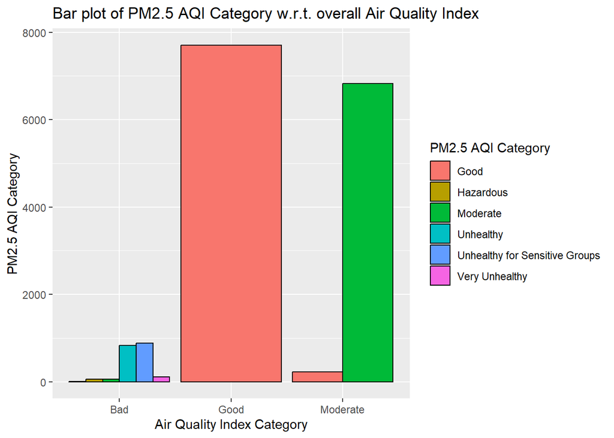

```r
plot_categorical_feature <- function(feature_name) {
  ggplot(data = dataset,
         aes(x = `Air Quality Index Category`, fill = !!rlang::sym(feature_name))) +
    geom_bar(stat = "count",
             color = "black",
             position = position_dodge()) +
    labs(
      y = feature_name,
      title = paste("Bar plot of", feature_name, "w.r.t. overall Air Quality Index")
    ) +
    scale_fill_discrete(labels = c(levels(dataset[[feature_name]]))) +
    scale_x_discrete(labels = c(levels(dataset$`Air Quality Index Category`)))
}

plot_categorical_feature("PM2.5 AQI Category")
```

It can be observed that there is a small overlap between the “Good” and “Moderate” categories in the *PM2.5 AQI Category*, while the other categories are well grouped. This indicates that it is easy to discriminate using this feature.

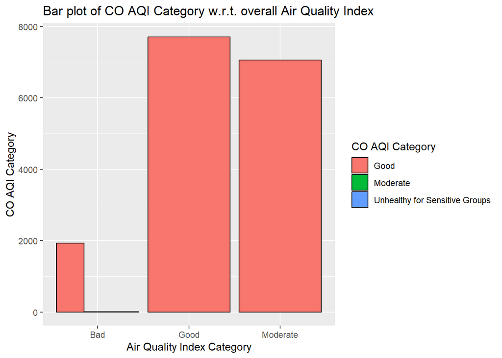

```r
plot_categorical_feature("CO AQI Category")
```

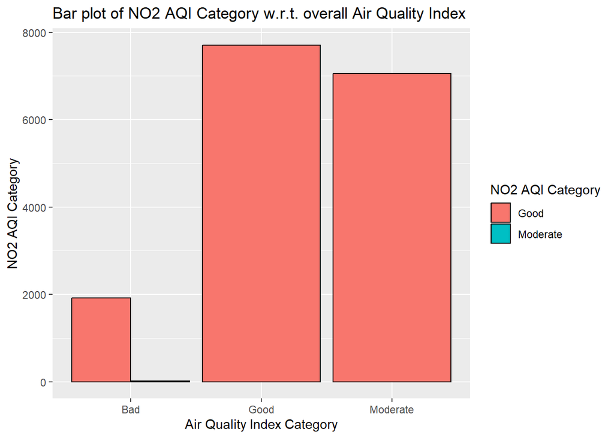

```r
plot_categorical_feature("NO2 AQI Category")
```

Is is noticeable that when it comes to *CO AQI Category* variable, patterns for prediction are difficult to identify, except for the “Moderate” and “Unhealthy for Sensitive Groups” categories. In the same way, it can be seen that for most of the records, the *NO2 AQI Category* has the “Good” value.

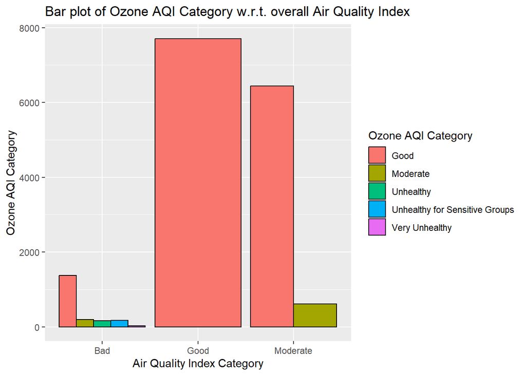

```r
plot_categorical_feature("Ozone AQI Category")
```

When examining the *Ozone AQI Category* variable, it becomes clear that identifying predictive patterns is challenging, with the exception of the “Unhealthy”, “Very Unhealthy” and “Unhealthy for Sensitive Groups” categories.

### Continuous Features

An important next step is to examine outliers - values that are outside of the range [mean +/- 3 * std](https://en.wikipedia.org/wiki/68%E2%80%9395%E2%80%9399.7_rule) - and the quartiles for the *PM2.5 AQI Value*, *CO AQI Value*, *NO2 AQI Value*, and *Ozone AQI Value* features. I plot these continuous features with a violin plot combined with a box plot because the first one highlights the distribution of the independent variable, while the second one depicts the outliers and the quartiles.

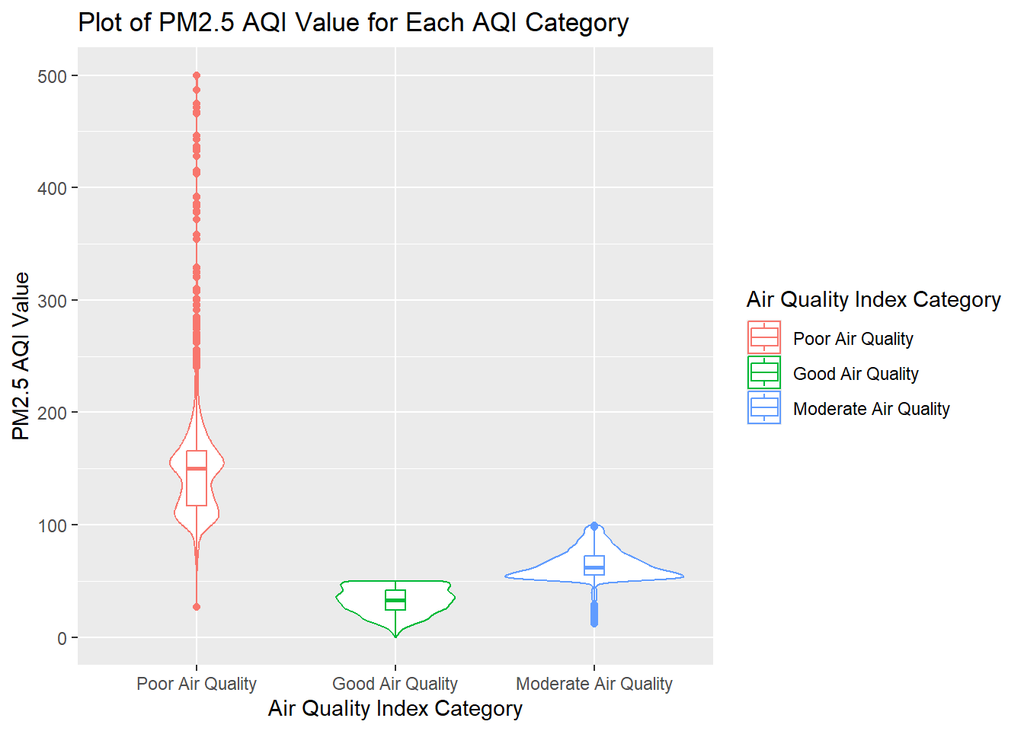

```r
plot_continuous_feature <- function(feature_name) {
  ggplot(
    data = dataset,
    aes(
      x = `Air Quality Index Category`,
      y = !!rlang::sym(feature_name),
      color = `Air Quality Index Category`
    )

  ) +
    geom_violin() + geom_boxplot(width = 0.1) +
    labs(title = paste("Plot of", feature_name, "for Each AQI Category")) +
    scale_x_discrete(
      labels = c(
        "Good" = "Good Air Quality",
        "Moderate" = "Moderate Air Quality",
        "Bad" = "Poor Air Quality"
      )
    ) +
    scale_color_discrete(
      labels = c(
        "Good" = "Good Air Quality",
        "Moderate" = "Moderate Air Quality",
        "Bad" = "Poor Air Quality"
      )
    )
}

plot_continuous_feature("PM2.5 AQI Value")
```

The distribution of PM2.5 AQI values varies by air quality category. In the Poor Air Quality category, values are heavily skewed toward higher levels, indicating significantly elevated PM2.5. In contrast, the Good Air Quality distribution is narrower and centered around lower values, suggesting that PM2.5 levels are generally low. Overlap exists between “Good” and “Moderate” categories, indicating some values may not clearly fit either classification.

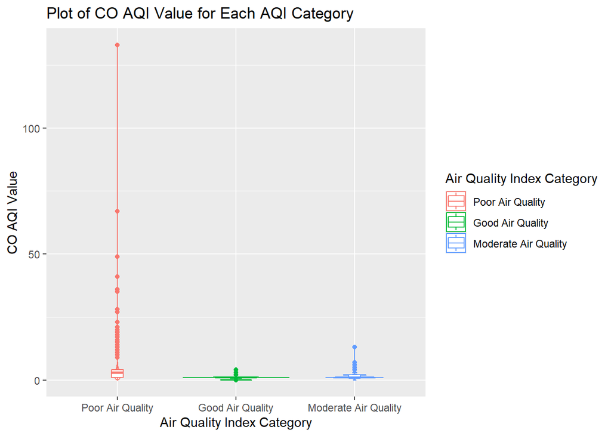

```r
plot_continuous_feature("CO AQI Value")
```

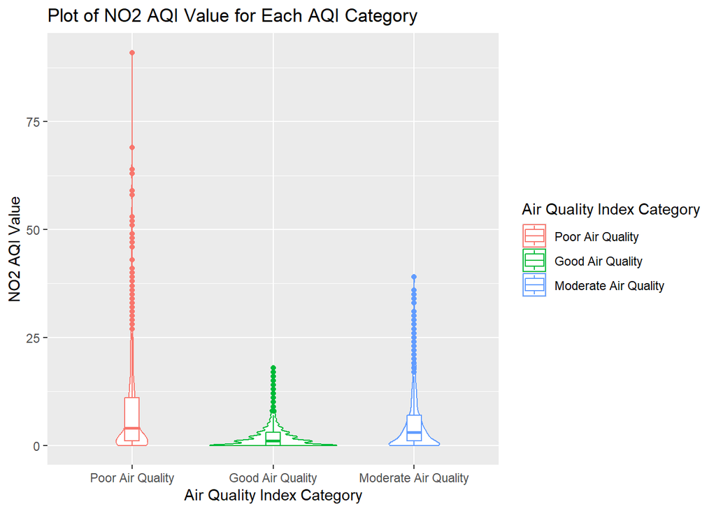

```r
plot_continuous_feature("NO2 AQI Value")
```

For NO2 AQI values, the distribution in the “Poor Air Quality” category is heavily skewed toward higher levels, indicating significantly elevated NO2. The “Good Air Quality” distribution is narrower and centered around lower levels, while “Moderate Air Quality” falls between the two, showing a wider range of values. Overlap between “Good” and “Moderate,” as well as “Moderate” and “Poor,” suggests potential ambiguity in categorization for certain NO2 values.

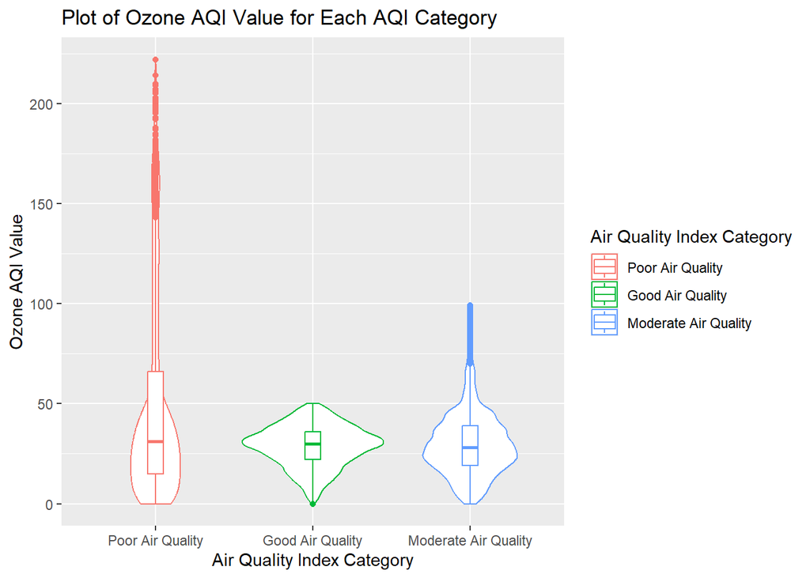

```r
plot_continuous_feature("Ozone AQI Value")
```

## Data Cleaning

It’s time to ensure our data is clean for training the model. To achieve this, I will filter the variables as explained in the previous sections and check for any missing values, filling them in if necessary.

### Data Filtering

This is how the dataset looks like after filtering the unnecessary features. After the grouping of AIQ Category, the new target column is named: *Air Quality Index Category*.

```r
dataset <- dataset %>% dplyr::select(
  Country,
  `CO AQI Value`,
  `CO AQI Category`,
  `Ozone AQI Value`,
  `Ozone AQI Category`,
  `NO2 AQI Value`,
  `NO2 AQI Category`,
  `PM2.5 AQI Value`,
  `PM2.5 AQI Category`,
  lat,
  lng,
  `Air Quality Index Category`
)
kable(dataset[1:5, ], "html") %>% kable_styling("striped") %>% scroll_box(width = "100%")
```

| Country | CO AQI Value | CO AQI Category | Ozone AQI Value | Ozone AQI Category | NO2 AQI Value | NO2 AQI Category | PM2.5 AQI Value | PM2.5 AQI Category | lat | lng | Air Quality Index Category |
| --- | --- | --- | --- | --- | --- | --- | --- | --- | --- | --- | --- |
| Russian Federation | 1 | Good | 36 | Good | 0 | Good | 51 | Moderate | 44.7444 | 44.2031 | Moderate |
| Brazil | 1 | Good | 5 | Good | 1 | Good | 41 | Good | -5.2900 | -44.4900 | Good |
| Brazil | 1 | Good | 5 | Good | 1 | Good | 41 | Good | -11.2958 | -41.9869 | Good |
| Italy | 1 | Good | 39 | Good | 2 | Good | 66 | Moderate | 37.1667 | 15.1833 | Moderate |
| Poland | 1 | Good | 34 | Good | 0 | Good | 20 | Good | 53.0167 | 20.8833 | Good |

### Missing Data Examination

```r
total_missing_dataset <- sum(is.na(dataset))
missing_values <- as.data.frame(mice::md.pattern(dataset, plot = FALSE))
missing_values <- missing_values %>%
  dplyr::rename("total missing values" = "V13")
t(tail(missing_values, 1))
```

```
##
## CO AQI Value                 0
## CO AQI Category              0
## Ozone AQI Value              0
## Ozone AQI Category           0
## NO2 AQI Value                0
## NO2 AQI Category             0
## PM2.5 AQI Value              0
## PM2.5 AQI Category           0
## lat                          0
## lng                          0
## Air Quality Index Category   0
## Country                    302
## total missing values       302
```

Unfortunately, the dataset contains 302 missing values, so additional steps are required to complete the data. However, since the missing values are limited to the country feature, I can fill them in using the corresponding city values, eliminating the need for any imputation methods. Sadly, without a Google Maps API Key (which requires to fill in my banking information) I did not succeed to create a automatic method to fill the missing countries. That is why I chose to drop the rows that have missing values, their number being a negligible one. In addition, I renamed all the columns and eliminate spaces to make the modeling step more straight-forward.

```r
dataset <- dataset %>%
  filter(!is.na(Country))

dataset <- dataset %>%
  rename(
    CO_AQI_Value = `CO AQI Value`,
    CO_AQI_Category = `CO AQI Category`,
    Ozone_AQI_Value = `Ozone AQI Value`,
    Ozone_AQI_Category = `Ozone AQI Category`,
    NO2_AQI_Value = `NO2 AQI Value`,
    NO2_AQI_Category = `NO2 AQI Category`,
    PM25_AQI_Value = `PM2.5 AQI Value`,
    PM25_AQI_Category = `PM2.5 AQI Category`,
    Air_Quality_Index_Category = `Air Quality Index Category`
  )

kable(dataset[1:5, ], "html") %>% kable_styling("striped") %>% scroll_box(width = "100%")
```

| Country | CO_AQI_Value | CO_AQI_Category | Ozone_AQI_Value | Ozone_AQI_Category | NO2_AQI_Value | NO2_AQI_Category | PM25_AQI_Value | PM25_AQI_Category | lat | lng | Air_Quality_Index_Category |
| --- | --- | --- | --- | --- | --- | --- | --- | --- | --- | --- | --- |
| Russian Federation | 1 | Good | 36 | Good | 0 | Good | 51 | Moderate | 44.7444 | 44.2031 | Moderate |
| Brazil | 1 | Good | 5 | Good | 1 | Good | 41 | Good | -5.2900 | -44.4900 | Good |
| Brazil | 1 | Good | 5 | Good | 1 | Good | 41 | Good | -11.2958 | -41.9869 | Good |
| Italy | 1 | Good | 39 | Good | 2 | Good | 66 | Moderate | 37.1667 | 15.1833 | Moderate |
| Poland | 1 | Good | 34 | Good | 0 | Good | 20 | Good | 53.0167 | 20.8833 | Good |

## Modeling

### Feature Selection

Then, the feature selection is performed using the Random Forest model and cross validation. First, I split the dataset into 10 folds using cross-validation, ensuring that each fold contained a portion of the data for testing while the rest was used for training. For each fold, I trained a Random Forest model to predict the AQI category and calculated feature importance scores. Features with importance scores above the average were selected for further use.

After selecting the most important features for each fold, I updated the list of frequently selected features across all folds. I used these features to retrain the model and make predictions on the test set, calculating precision and recall for each fold. Finally, I computed the overall F1 score to measure the model’s performance and identified the most important features based on their selection frequency. The final dataset was then filtered to include only the most important features along with the AQI category for further analysis.

```r
set.seed(194)

folds <- caret::createFolds(dataset$Air_Quality_Index_Category, k = 10)

precisions <- c()
recalls <- c()
feature_counts <- table(character())

for (fold_index in 1:length(folds)) {
  test_fold <- as.data.frame(dataset[folds[[fold_index]], ])
  train_fold <- as.data.frame(dataset[-folds[[fold_index]], ])
  rf_model <-  randomForestSRC::rfsrc(
    Air_Quality_Index_Category ~ .,
    data = train_fold,
    importance = TRUE,
    ntree = 1,
    imbalanced = TRUE
  )

  importance_scores <- rf_model$importance[, "all"]
  mean_importance <- mean(importance_scores)
  selected_features <- names(importance_scores[importance_scores >= mean_importance])

  fold_features <- table(selected_features)
  feature_counts <- table(c(names(feature_counts), names(fold_features)))

  selected_features_string = paste(selected_features, collapse = "+")
  formula = as.formula(paste("Air_Quality_Index_Category ~", selected_features_string))
  final_rf_model <- randomForestSRC::rfsrc(formula,
                                           data = train_fold,
                                           ntree = 1,
                                           imbalanced = TRUE)

  predictions = predict(final_rf_model, test_fold)
  confusion_matrix <- confusionMatrix(factor(predictions$class),
                                      factor(test_fold$Air_Quality_Index_Category))
  precisions <- append(precisions, confusion_matrix$byClass[, "Pos Pred Value"])
  recalls <- append(recalls, confusion_matrix$byClass[, "Sensitivity"])
}

mean_precision <- mean(precisions, na.rm = TRUE)
mean_recall <- mean(recalls, na.rm = TRUE)
mean_f1_score <- 2 * (mean_precision * mean_recall) / (mean_precision + mean_recall)
sorted_features <- sort(feature_counts, decreasing = TRUE)

print(paste("F1 Score:", mean_f1_score))
```

```
## [1] "F1 Score: 0.999686296888294"
```

```r
selected_features = as.vector(as.data.frame(sorted_features)[["Var1"]])
formula <- as.formula(paste(
  "Air_Quality_Index_Category ~",
  paste(selected_features, collapse = " + ")
))
print(selected_features)
```

```
## [1] "Ozone_AQI_Category" "Ozone_AQI_Value"    "PM25_AQI_Category"
## [4] "PM25_AQI_Value"     "CO_AQI_Value"       "NO2_AQI_Value"
```

### Tuning

Next, I found the optimal `mtry` (the number of variables randomly selected at each split) for my selected features and dataset. This is done on the whole dataset. I tested values from 2 to 6 (the number of selected features). Moreover, I displayed the F1 score for each selected `mtry` value.

```r
f1 <- function(data, lev = NULL, model = NULL) {
  f1_val <- f1_score(data$pred, data$obs)
  names(f1_val) <- c("F1")
  f1_val
}

f1_score <- function(predicted, expected) {
  predicted <- factor(as.character(predicted), levels = unique(as.character(expected)))
  expected  <- as.factor(expected)

  cm = as.matrix(table(expected, predicted))
  cm <- cm[order(rownames(cm)), order(colnames(cm))]
  precision <- diag(cm) / colSums(cm)
  recall <- diag(cm) / rowSums(cm)
  f1 <-  ifelse(precision + recall == 0,
                0,
                (2 * precision * recall) / (precision + recall))
  f1[is.na(f1)] <- 0

  mean(f1)
}

mtry_values <- c(2:length(selected_features))
optimization_control <- trainControl(
  method = 'cv',
  number = 5,
  summaryFunction = f1,
  classProbs = TRUE
)

tuned_rf <- caret::train(
  formula,
  data = dataset,
  method = 'rf',
  metric = "F1",
  tuneGrid = expand.grid(.mtry = mtry_values),
  trControl = optimization_control
)
optimal_mtry <- tuned_rf$finalModel$mtry

kable(tuned_rf$results %>% dplyr::select(c(mtry, F1)))
```

| mtry | F1 |
| --- | --- |
| 2 | 0.9998907 |
| 3 | 0.9998907 |
| 4 | 0.9998907 |
| 5 | 0.9998907 |
| 6 | 0.9998889 |

```r
paste("The optimal m is", optimal_mtry)
```

```
## [1] "The optimal m is 2"
```

### Validation

**Train/Test Validation**

Next, with the optimal number of variables randomly selected at each split, I can train the tuned random forest model on the training dataset (80%) and validate it using the test dataset (20%).

```r
dataset_splitter_rf <- initial_split(dataset, prop = 0.8, strata = Air_Quality_Index_Category)
train_dataset_rf <- as.data.frame(training(dataset_splitter_rf))
test_dataset_rf <- as.data.frame(testing(dataset_splitter_rf))

tuned_rf_model <- rfsrc(formula, data = train_dataset_rf, mtry = optimal_mtry)
predictions <- predict(tuned_rf_model, newdata = test_dataset_rf, importance = TRUE)

confusion_matrix <- confusionMatrix(factor(predictions$class),
                                    factor(test_dataset_rf$Air_Quality_Index_Category))
precision <- confusion_matrix$byClass[, "Pos Pred Value"]
recall <- confusion_matrix$byClass[, "Sensitivity"]

mean_precision <- mean(precision, na.rm = TRUE)
mean_recall <- mean(recall, na.rm = TRUE)
validation_model_f1_score <- 2 * (mean_precision * mean_recall) / (mean_precision + mean_recall)
cat_mutual_information <- infotheo::mutinformation(dataset$Air_Quality_Index_Category,
                                                   dataset$PM25_AQI_Category)
value_mutual_information <- infotheo::mutinformation(dataset$Air_Quality_Index_Category, dataset$PM25_AQI_Value)

print(paste("Validation F1 Score:", validation_model_f1_score))
```

```
## [1] "Validation F1 Score: 1"
```

**Observations**: The F1 score might appear higher than expected, but this is likely due to the strong correlation between the target column and the `PM2.5` features After computing the mutual information, I found that it is approximately 0.891482 for *PM25_AQI_Category* and 0.898789 for *PM25_AQI_Value*, indicating a significant relationship between these variables. This strong association can justify the large F1 score.

**Cross Validation**

```r
control <- caret::trainControl(
  method = "cv",
  number = 100,
  summaryFunction = f1,
  classProbs = TRUE
)

model <- caret::train(
  formula,
  data = dataset,
  method = 'rf',
  metric = "F1",
  tuneGrid = expand.grid(.mtry = c(optimal_mtry)),
  trControl = optimization_control
)


avg_F1 <- mean(model$resample$F1)
lower_bound <- quantile(model$resample$F1, 0.025)
upper_bound <- quantile(model$resample$F1, 0.975)
print(
  paste(
    "Random Forest",
    "95% conficence intervals:",
    lower_bound,
    ", ",
    avg_F1,
    ", ",
    upper_bound
  ),
)
```

```
## [1] "Random Forest 95% conficence intervals: 0.999508009526606 ,  0.99989066878369 ,  1"
```

## Final Model

Finally, I trained the final model, with the best selected features, the optimal `mtry` value, and using the whole dataset. There can be seen that the most important feature in predicting air quality categories is `PM25_AQI_Category`, followed by `Ozone_AQI_Category`, and `PM25_AQI_Value`. The least significant features are `No2_AQI_Value` and `CO_AQI_Value`.

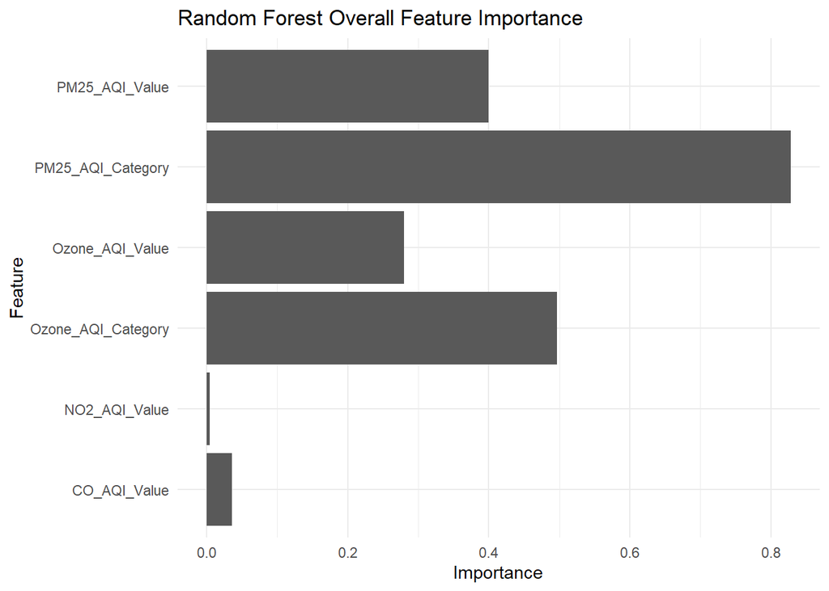

```r
final_rf_model = rfsrc(
  formula,
  data = as.data.frame(dataset),
  mtry = optimal_mtry,
  importance = TRUE
)

feature_importance_df <- as.data.frame(final_rf_model$importance)
feature_importance_all <- data.frame("feature" = rownames(feature_importance_df),
                                     "all" = feature_importance_df$all) %>% arrange(desc(all))

ggplot(feature_importance_all, aes(x = feature, y = all)) +
  geom_bar(stat = "identity") +
  labs(title = "Random Forest Overall Feature Importance", x = "Feature", y = "Importance") +
  theme_minimal() +
  coord_flip()
```

## Conclusion

In conclusion, I’ve identified the key features that drive air quality predictions. Given the simplicity of my dataset, the model performs exceptionally well, with an almost perfect F1 score. Looking ahead, there’s potential for improvement by removing the outlines from the data and expanding the dataset to include more information. This could open up opportunities to explore correlations between location and air quality.